# Individual #1

Jacob Shoemaker; jshoemaker2249

4/11/2019

```r
acc <- read.csv("https://raw.githubusercontent.com/xdaiISU/ds202materials/master/hwlabs/fars2017/accident.csv", stringsAsFactors = FALSE)
per <- read.csv("https://raw.githubusercontent.com/xdaiISU/ds202materials/master/hwlabs/fars2017/person.csv", stringsAsFactors = FALSE)
```

are there some days of the week where more accidents happen than on others (use variable DAY_WEEK)? what time of the day do accidents happen (use variable HOUR)? what is the number of accidents with at least one drunk driver (use variable DRUNK_DR)?

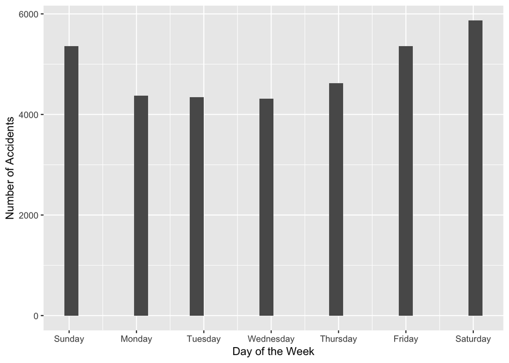

```r
library(ggplot2)
ggplot(acc, aes(x=DAY_WEEK))+ geom_histogram() + scale_x_continuous(breaks = seq(1,7,1), labels = c("Sunday", "Monday", "Tuesday", "Wednesday", "Thursday", "Friday", "Saturday")) + xlab("Day of the Week") + ylab("Number of Accidents")
```

```r
library(plyr)
library(dplyr)
```

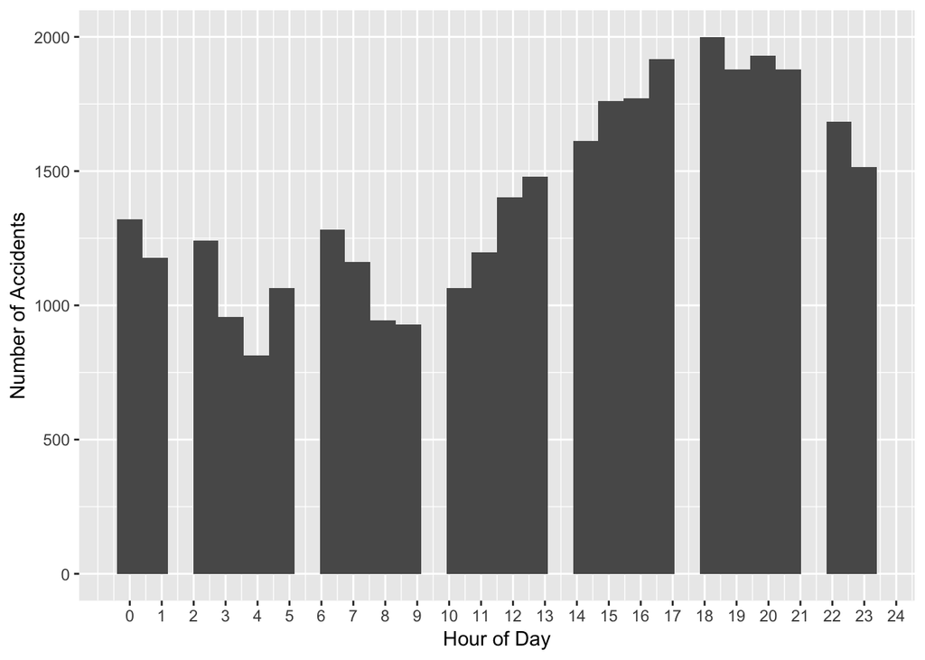

```r
dat <- filter(acc, acc$HOUR <= 24)
ggplot(dat, aes(x=HOUR)) + geom_histogram() + scale_x_continuous(breaks = seq(0,24,1)) + xlab("Hour of Day") + ylab("Number of Accidents")
```

The most accidents happen in the evening, between 6pm and 9pm.

```r
drunk <- filter(acc, acc$DRUNK_DR >= 1)
drunk %>% summarise(numAcc = n())
```

```
##   numAcc
## 1   8769
```

There have been 8,769 accidents with at least one drunk driver.

Load the person table. Identify drivers (PER_TYP == 1, see fars manual) and subset on them. Join accident and driver table (work out which variable(s) to use) Tally the number of accidents by day of the week (DAY_WEEK), hour of the day (HOUR) and gender (SEX). Visualize the results!

```r
drivers <- subset(per, PER_TYP ==1)
dat <- join(drivers, acc, type= "inner")
dat %>% group_by(DAY_WEEK) %>% summarize(count = n())
```

```
## # A tibble: 7 x 2
##   DAY_WEEK count
##      <int> <int>
## 1        1  7758
## 2        2  6821
## 3        3  6744
## 4        4  6778
## 5        5  7212
## 6        6  8354
## 7        7  8607
```

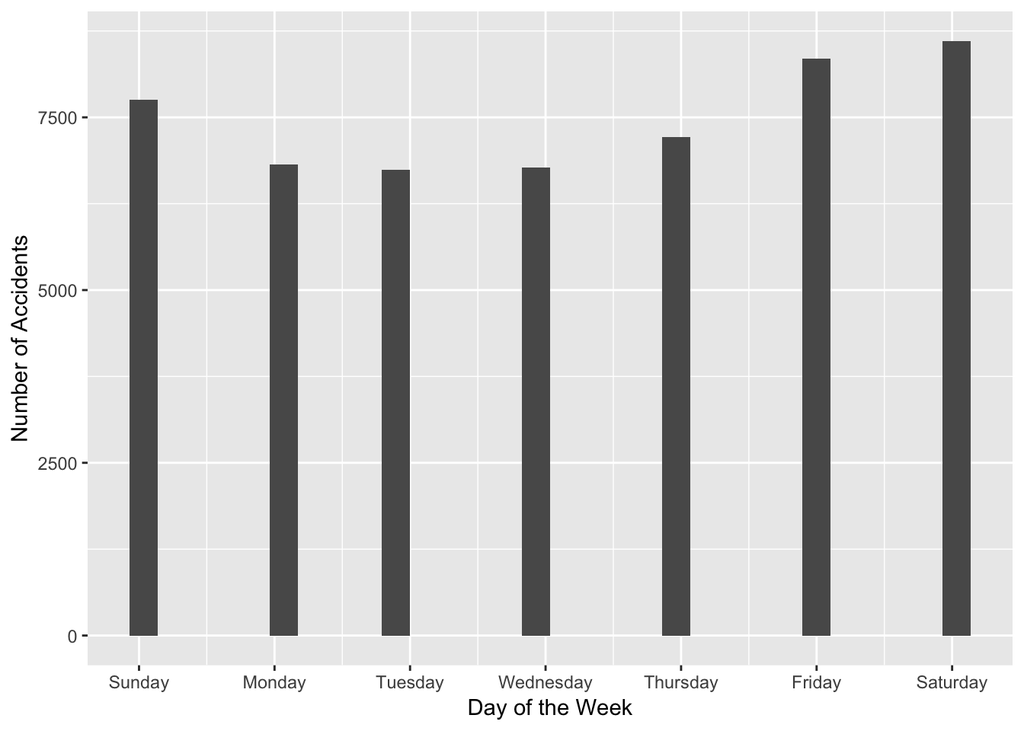

```r
ggplot(dat, aes(x=DAY_WEEK))+ geom_histogram() + scale_x_continuous(breaks = seq(1,7,1), labels = c("Sunday", "Monday", "Tuesday", "Wednesday", "Thursday", "Friday", "Saturday")) + xlab("Day of the Week") + ylab("Number of Accidents")
```

```r
filter(dat, dat$HOUR <= 24) %>% group_by(HOUR) %>% summarise(count = n())
```

```
## # A tibble: 24 x 2
##     HOUR count
##    <int> <int>
##  1     0  1734
##  2     1  1505
##  3     2  1630
##  4     3  1223
##  5     4  1076
##  6     5  1532
##  7     6  1958
##  8     7  1894
##  9     8  1527
## 10     9  1561
## # … with 14 more rows
```

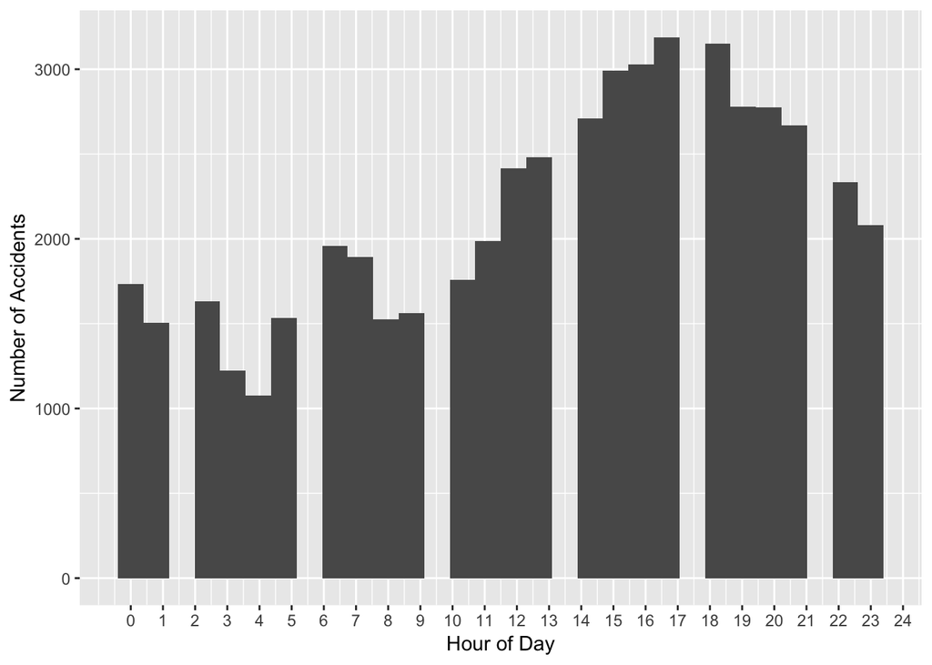

```r
dat1 <- filter(dat, dat$HOUR <= 24)
ggplot(dat1, aes(x = HOUR)) + geom_histogram() + scale_x_continuous(breaks = seq(0,24,1)) + xlab("Hour of Day") + ylab("Number of Accidents")
```

```r
dat %>% group_by(SEX) %>% summarise(count = n())
```

```
## # A tibble: 4 x 2
##     SEX count
##   <int> <int>
## 1     1 37654
## 2     2 13555
## 3     8   110
## 4     9   955
```

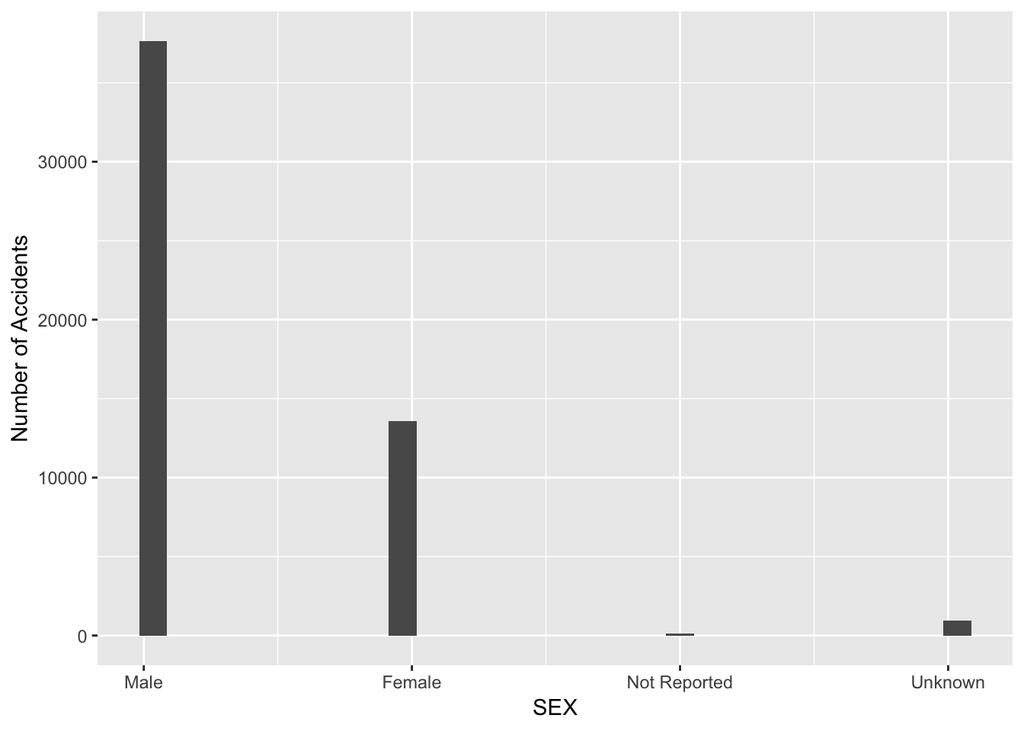

```r
dat$SEX <- ifelse(dat$SEX == 8, 3, dat$SEX)
dat$SEX <- ifelse(dat$SEX == 9, 4, dat$SEX)
ggplot(dat, aes(x=SEX)) + geom_histogram() + scale_x_continuous(breaks = seq(1,4,1), labels = c("Male", "Female","Not Reported", "Unknown")) + ylab("Number of Accidents")
```

Now plot a choropleth map of accidents on a county level Read the description for the STATE and COUNTY columns in the FARS manual. The state & county codes are Geographic Locator Codes (GLCs) from the General Services Administration’s (GSA) publication Use readxl::read_xlsx to read in the GLCs Visualize the number of accidents in each county using a choropleth map. To do this, you need to join the accident data, GLCs, and appropriate map data. Can you find seasonal trends in accident occurrences in different states? Is summer or winter more dangerous? Why?

```r
glcs <- readxl::read_excel("FRPP GLC United States.xlsx", skip = 1)
library(tidyverse)
library(lubridate)
```

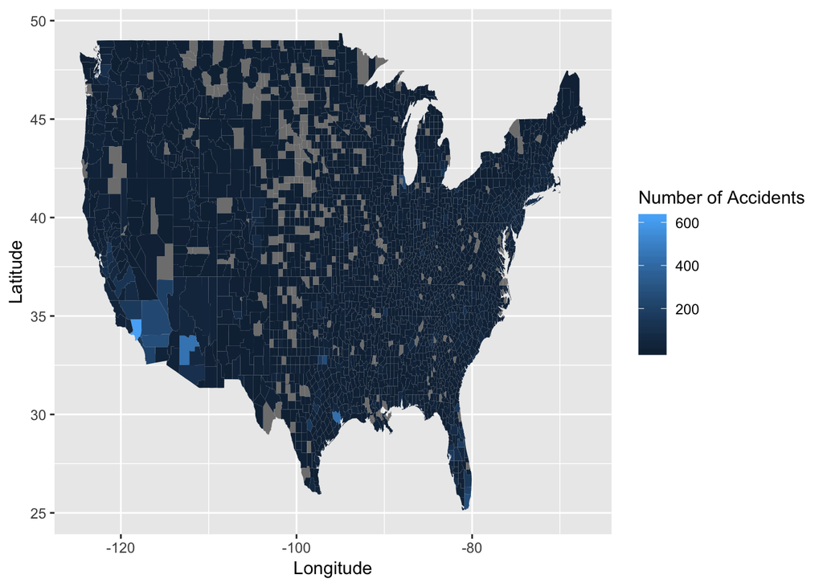

```r
library(maps)
counties <- map_data('county')

glcs1<- glcs
acc1 <- acc
counties1 <- counties

glcs1$STATE <- glcs1$`State Code`
glcs1$COUNTY <- glcs1$`County Code`

glcs1 <- glcs1 %>% select("STATE", "State Name", "COUNTY", "County Name")
acc1 <- acc1 %>% select("STATE", "COUNTY", "ST_CASE")

geo1 <- acc1 %>% join(glcs1)
geo1 <- geo1 %>% distinct()
geo1$region <- geo1$`State Name`
geo1$subregion <- geo1$`County Name`
geo1 <- geo1 %>% select(-c("STATE", "COUNTY", "State Name", "County Name"))
geo1$region <- tolower(geo1$region)
geo1$subregion <- tolower(geo1$subregion)
glcs_acc <- geo1 %>% group_by(region, subregion) %>% summarise(numAcc = n())
final <- counties1 %>% join(glcs_acc)
ggplot(final, aes(x=long, y=lat, fill=numAcc)) + geom_polygon(aes(group=group)) + xlab("Longitude") + ylab("Latitude") + labs(fill = "Number of Accidents")
```